# Problem Set 1 Answers

ylelkes

September 14, 2015

For now, copy and paste your commands and results (including figures) into a word document.

1. Suppose you track your commute times for two weeks (10 days) and you find the following times in minutes: 17 16 20 24 22 15 21 15 17 22

```r
commute <- c(17, 16,20,24,22,15,21,15,17,22)
```

```
* Use the function max to find the longest commute time, the function mean to find the average and the function min to find the minimum.
```

```r
max(commute)
```

```
## [1] 24
```

```r
mean(commute)
```

```
## [1] 18.9
```

```r
min(commute)
```

```
## [1] 15
```

- Oops, the 24 was a mistake. It should have been 18. How can you fix this without rewriting the vector? Do so, and then find the new average.

```r
commute[4]=18
commute[commute==24]=18
commute <- car::recode(commute,"24=18")
mean(commute)
```

```
## [1] 18.3
```

- How many times was your commute 20 minutes or more? Hint: try using sum() and a logical statement. [Read here about logical operators](http://www.statmethods.net/management/operators.html)

```r
commute>20
```

```
##  [1] FALSE FALSE FALSE FALSE  TRUE FALSE  TRUE FALSE FALSE  TRUE
```

```r
sum(commute>20)
```

```
## [1] 3
```

- What percent of your commutes are less than 17 minutes?

```r
commute>20
```

```
##  [1] FALSE FALSE FALSE FALSE  TRUE FALSE  TRUE FALSE FALSE  TRUE
```

```r
sum(commute<17)/length(commute)*100
```

```
## [1] 30
```

```r
scales::percent(sum(commute<17)/length(commute))
```

```
## [1] "30%"
```

- Replace the 5th element of the vector with NA. Calculate the new mean.

```r
commute[5]<- NA
mean(commute)
```

```
## [1] NA
```

```r
mean(commute,na.rm=T)
```

```
## [1] 17.88889
```

2. The Crimean War
   - Install the HistData package and load Nightingale. Read about it [here](https://vincentarelbundock.github.io/Rdatasets/doc/HistData/Nightingale.html)
   - How many people died of Wounds? How many people died of Disease?

```r
library(HistData)
data(Nightingale)
sum(Nightingale$Wounds)
```

```
## [1] 1758
```

```r
sum(Nightingale$Disease)
```

```
## [1] 14476
```

```
* Create a piechart using the pie() command. You should have a slice for # of ppl dying of wounds, # of ppl dying of disease, # of ppl dying of other. Make sure to label all the slices. Give your graph a title. If you wish, change the colors.
```

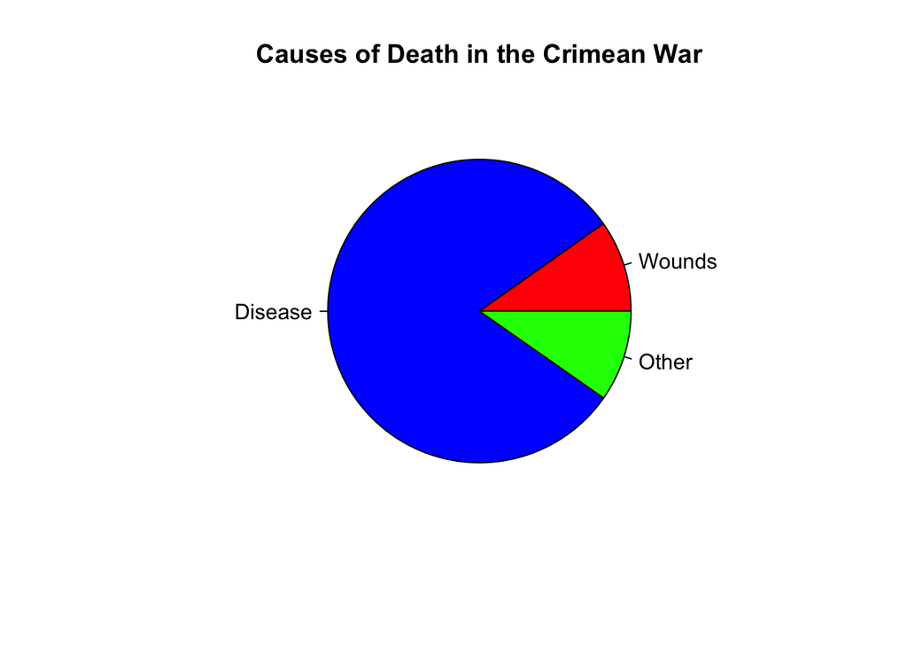

```r
pie(x = c(sum(Nightingale$Wounds),sum(Nightingale$Disease),sum(Nightingale$Other)),labels = c("Wounds","Disease","Other"),main = "Causes of Death in the Crimean War",col = c("red","blue","green"))

with(Nightingale, pie(x = c(sum(Wounds),sum(Disease),sum(Other)),labels = c("Wounds","Disease","Other"),main = "Causes of Death in the Crimean War",col = c("red","blue","green")))
```

3. Loading data into R
   - We didn’t get to this in class, but loading data into R will be central to your life as a data analysist.
   - Download the following files into your working directory (hint: use getwd())
     - If you want to make it more challenging, read it directly from the web (without downloading it to your working directory).
     - https://raw.githubusercontent.com/ylelkes/R_wav/master/data%20examples/Countries-Europe.csv
     - https://github.com/ylelkes/R_wav/blob/master/data%20examples/child_data.sav?raw=true
     - https://github.com/ylelkes/R_wav/blob/master/data%20examples/GaltonFamilies.dta?raw=true

```r
library(RCurl)
europe <- rio::import(("https://rawgit.com/ylelkes/R_wav/master/data%20examples/Countries-Europe.csv"))
childdata <- rio::import("https://rawgit.com/ylelkes/R_wav/master/data%20examples/child_data.sav")
galton <- rio::import("https://rawgit.com/ylelkes/R_wav/master/data%20examples/GaltonFamilies.dta")
```

```
* Using read.csv, the foreign package, or haven load each one of these datasets into R.
* For: "Countries-Europe.csv" (let's call that object europe)
    * What is the median population of Europe?
```

```r
median(europe$population)
```

```
## [1] 4907000
```

- What is the mean population/land area

```r
mean(europe$population/europe[,7])
```

```
## [1] 646.5028
```

```r
mean(europe$population/europe$land)
```

```
## [1] 646.5028
```

- If you replace X and Y in the following, you will get most populated country in Europe: `europe$X[europe$Y==max(europe$population)]`

```r
europe$name[europe$population==max(europe$population)]
```

```
## [1] "Germany"
```

- What variable is X? What variable is Y? * In your own words, describe what this command is doing..
- For GaltonFamilies.dta: * using the cor() command, what is the correlation between a child’s height and his mother’s height and what is the correlation between the child’s height and the father’s height?

```r
fatherchild <- cor(galton$childHeight,galton$father)
motherchild <- cor(galton$childHeight,galton$mother)
```

```
    * Use a logical statement, get R to confirm that the first correlation does not equal the second correlation.
```

```r
fatherchild == motherchild
```

```
## [1] FALSE
```

- Using lm(), is there a relationship between the father’s height and the number of children he has?

```r
summary(lm(father~childHeight,galton))
```

```
##
## Call:
## lm(formula = father ~ childHeight, data = galton)
##
## Residuals:
##     Min      1Q  Median      3Q     Max
## -6.6917 -1.4279  0.0601  1.4893  8.8880
##
## Coefficients:
##             Estimate Std. Error t value Pr(>|t|)
## (Intercept) 56.91107    1.46030  38.972   <2e-16 ***
## childHeight  0.18407    0.02185   8.425   <2e-16 ***
## ---
## Signif. codes:  0 '***' 0.001 '**' 0.01 '*' 0.05 '.' 0.1 ' ' 1
##
## Residual standard error: 2.389 on 932 degrees of freedom
## Multiple R-squared:  0.07078,    Adjusted R-squared:  0.06978
## F-statistic: 70.99 on 1 and 932 DF,  p-value: < 2.2e-16
```

- For child_data.sav * What is the memory span of child with the highest IQ?

```r
childdata$MEM_SPAN[childdata$IQ==max(childdata$IQ)]
```

```
## [1] 3.9
```

- Create a correlation table for the entire dataset

```r
cortab <- cor(childdata)
```

```
    * From the correlation table, extract the correlation between memory span & IQ, the correlation between age and reading ability, and the correlation between IQ and reading ability into a vector
```

```r
c(cortab[2,3],cortab[1,4],cortab[3,4])
```

```
## [1] 0.3024664 0.8459897 0.1503958
```

- write that vector to a csv file.

```r
write.csv(c(cortab[2,3],cortab[1,4],cortab[3,4]),file="cortabl.csv")
```